# Zooplancton classes réduites

```r
SciViews:: R
zooplankton <- read( file = "zooplankton", package = "data.io", lang = "fr")
zooplankton_sub <- filter(zooplankton, class %in% c("Poecilostomatoid", "Calanoid", "Cyclopoid", "Harpacticoid"))
```

```r
library(ggridges)
```

# 1 Introduction

Cette recherche porte sur l’étude morphologique des zooplanctons de Tulear et Madagascar, et plus précisément sur les copépodes. Je vais présenter plusieurs graphiques et test dans ce rapport d’analyses.

# 2 Matériel et méthodes

Diverses caractéristiques ont été mesurées par analyse d’image avec le package zooimage et ImageJ sur des échantillons de zooplancton provenant de Tuléar, à Madagascar.

# 3 But

Déterminer l’influence de la sous-classes des copépodes des zooplanktons de Tuléar dont les ordres sont Poécilostomatoïde, Calanoïdes, Harpacticoïde et Cyclopoïde, sur leurs paramètres corporels, comme par exemple leur taille, leur transparence,..

# 4 Statistiques

Dans ce rapport je vais utiliser le test de l’ANOVA et le test post-hoc de Tukey.

ANOVA : ce test consiste émettre l’hypothèse que les moyennes d’un nombre k de populations (4 dans ce cas ci) sont égales. Lorsqu’on rejète cette hypothèse car la valeur de P est inférieure au seuil alpha, cela signifie qu’au moins deux moyennes diffèrent l’une de l’autre mais nous ne savons pas lesquelles.

Test post-hoc de Tukey : lorsque que l’on rejète H0 après une ANOVA, on effectue un test post-hoc de Tukey pour savoir quelles moyennes diffèrent l’une de l’autre. C’est un test de comparaison deux à deux mais avec un risque de se tromper moindre que dans un test classique de comparaison pour 2 populations comme le test de t Student par exemple.

# 5 Résultats

## 5.1 Graphique en camembert du nombre d’individus en fonction des ordres de copépodes

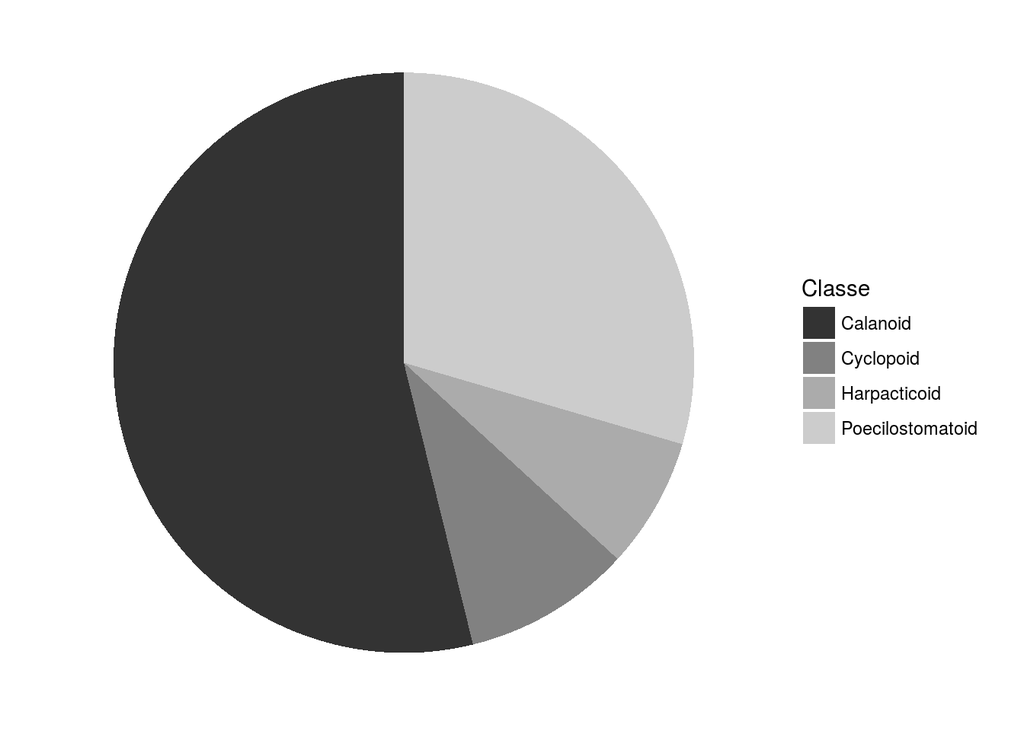

```r
chart(data = zooplankton_sub, ~ factor(0) %fill=% class) +
  geom_bar(width = 1) +
  coord_polar("y", start = 0) +
  theme_void() +
  scale_fill_grey()
```

On peut voir qu’il y a beaucoup plus de CalanoÏdes étudiés que de Poécilostomatoïdes, Harpaticoïdes et Cyclopoïdes.

## 5.2 Graphique en colonne de la surface de l’individu en fonction de l’ordre de copépodes

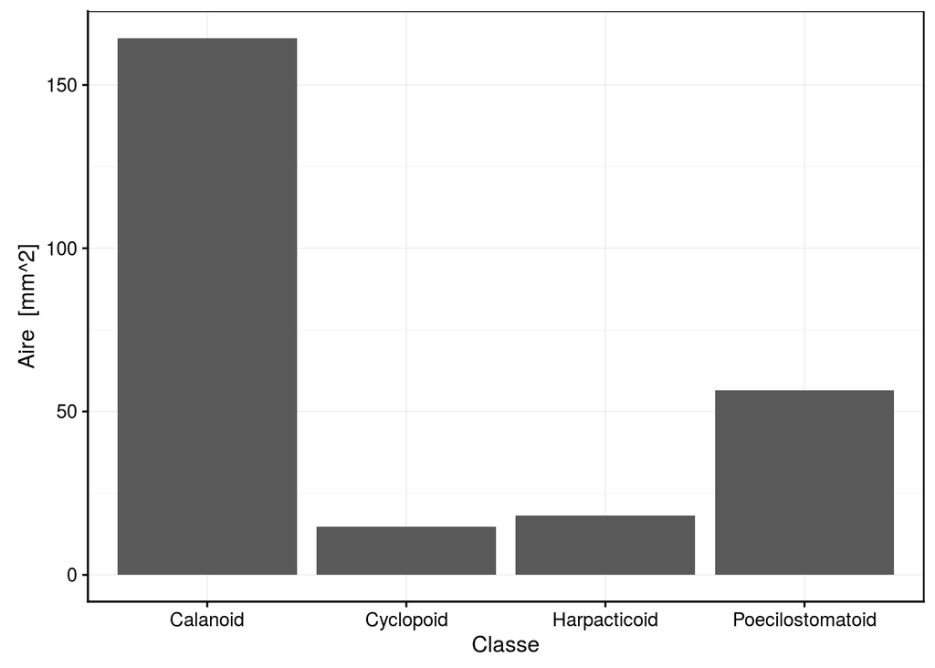

```r
chart(zooplankton_sub, formula = area ~ class) +
  geom_col()
```

On peut observer ici que l’ordre des Calanoïdes a une surface grandement supérieure aux troix autres ordres.

L’ordre de Poécilostomatoïdes à une surface trois fois inférieure à la classe des Calanoïdes, mais il a aussi une surface trois fois supérieure aux ordres des Cyclopoïdes et des Harpacticoïdes qui eux ont approximativement la même surface.

Cela est surement dû au fait que le nombre d’individus étudiés dans chaque ordre est grandement différent.

## 5.3 Graphique en colonne du périmètre selon l’ordre de copépodes

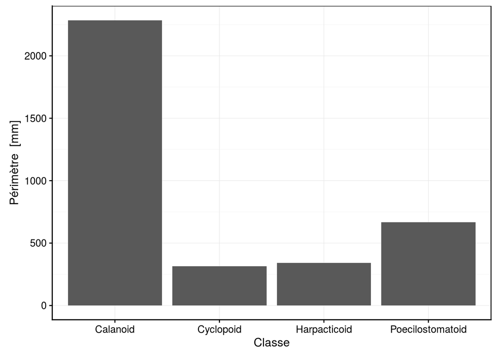

```r
chart(zooplankton_sub, perimeter ~ class) +
  geom_col()
```

En toute logique, on observe pratiquement la même chose que pour le graphique comparant les surfaces en fonction des ordres. Les Calanoïdes ont le plus grand périmètre, suivis par les Poécilostomatoïdes qui ont un périmètre environ 3.6 fois inférieur. Les Cyclopoïdes et Harpaticoïdes ont pratiquement le même périmètre.

Cela est surement dû au fait que le nombre d’individus étudiés dans chaque ordre est grandement différent.

## 5.4 Boxplot de la taille de l’axe mineur de l’ellipsoïde en fonction de l’ordre de copépodes

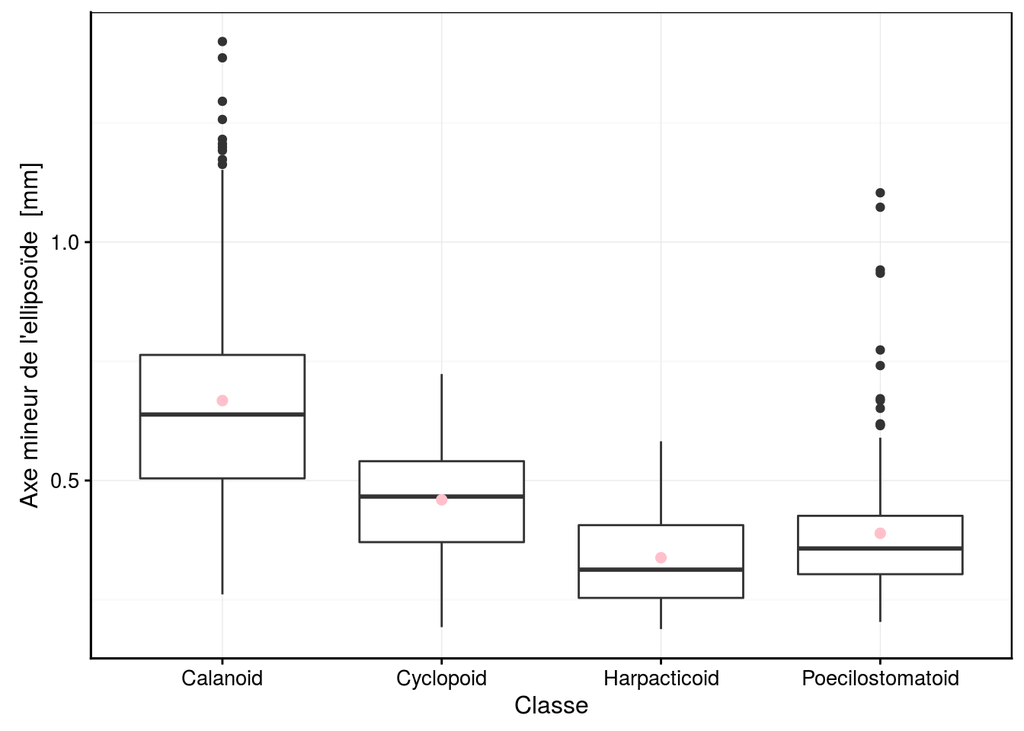

```r
chart(zooplankton_sub, formula = minor ~ class) +
  geom_boxplot() +
  stat_summary(geom= "point", fun.y= "mean", color= "pink", size= 2)
```

Dans l’ordre des Calanoïdes et des Poécilostomatoïdes, il y a beaucoup d’invidus présentant une valeur extrême pour l’axe mineur de l’élipsoïde, ce qui explique pourquoi le point de la moyenne des indidus ne se situe pas sur la médiane, les valeurs extrêmes faussent la moyenne.

Par contre, pour les Cyclopoïdes et les Harpaticoïdes, il n’y a pas de valeurs extrêmes donc la moyenne est très proche de la valeur de la médiane.

## 5.5 Boxplot de la taille de l’axe majeur de l’ellipsoïde en fonction de l’ordre de copépodes

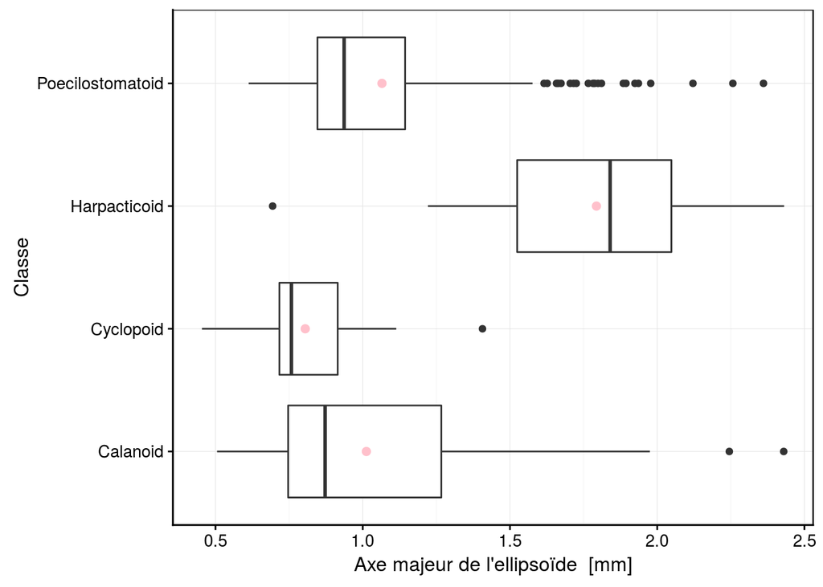

```r
chart(zooplankton_sub, formula = major ~ class) +
  geom_boxplot() +
  stat_summary(geom= "point", fun.y= "mean", color= "pink", size= 2) +
  coord_flip()
```

Par contre, pour les Cyclopoïdes et les Harpaticoïdes, il n’y a qu’une seule valeur extrême, donc la moyenne est très proche de la valeur de la médiane.

## 5.6 Graphique de densité de l’élongation en fonction de l’ordre de copépodes

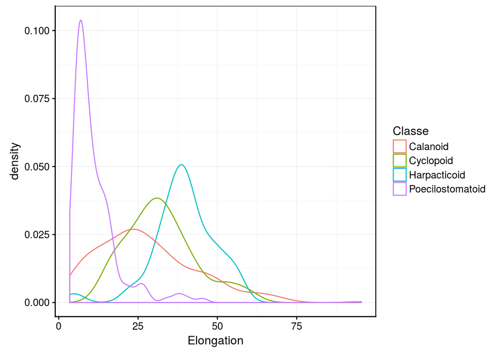

```r
chart(zooplankton_sub, ~ elongation %col=% class) +
  geom_density(bins=30)
```

On peut voir que les Calanoïdes ont une élongation entre 6 et 50 en majorité avec quelques exceptions au delà de 50.

Les Cyclopoïdes eux ont une élongation entre 12,5 et 45, les Harpaticoïdes entre 25 et 60.

Les Poécilostomatoïdes eux ont quasiment tous une élongation entre 4 et 18.

## 5.7 Graphique en colonne de densité de la densité optique en fonction de l’ordre de copépodes

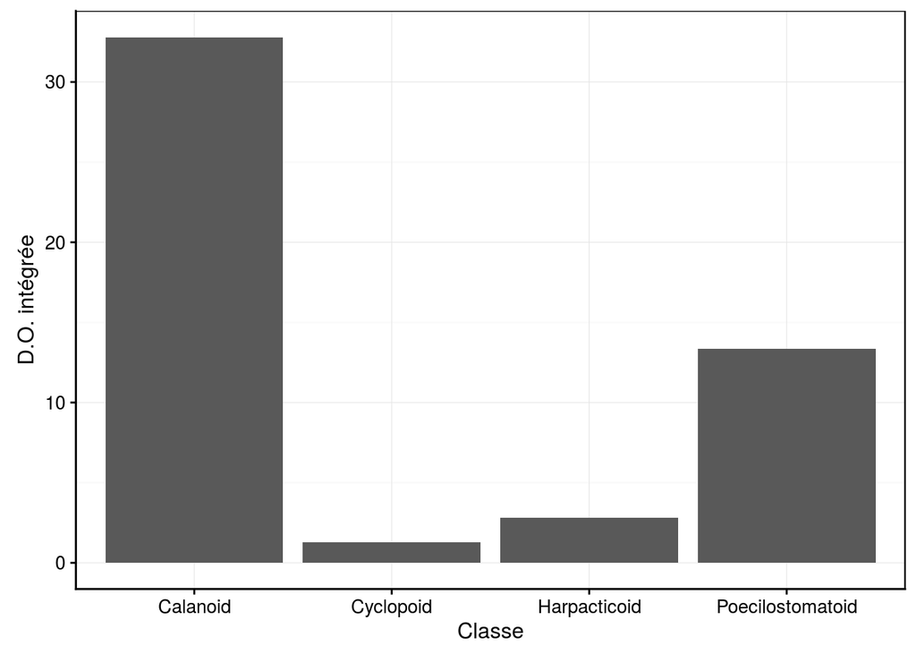

```r
chart(zooplankton_sub,formula= density ~ class  )+
  geom_col()
```

Les Calanoïdes ont une densité optique supérieure à 30, ce qui peut s’expliquer par leur grande taille. Les Poécilostomatoïdes ont une densité optique presque égale à 15, ils ont une taille moyenne. Les Cyclopoïdes et les Harpaticoïdes ont une des densités optiques similaires et inférieures à 5.

## 5.8 Graphique en colonne de la circularité selon l’ordre de copépodes

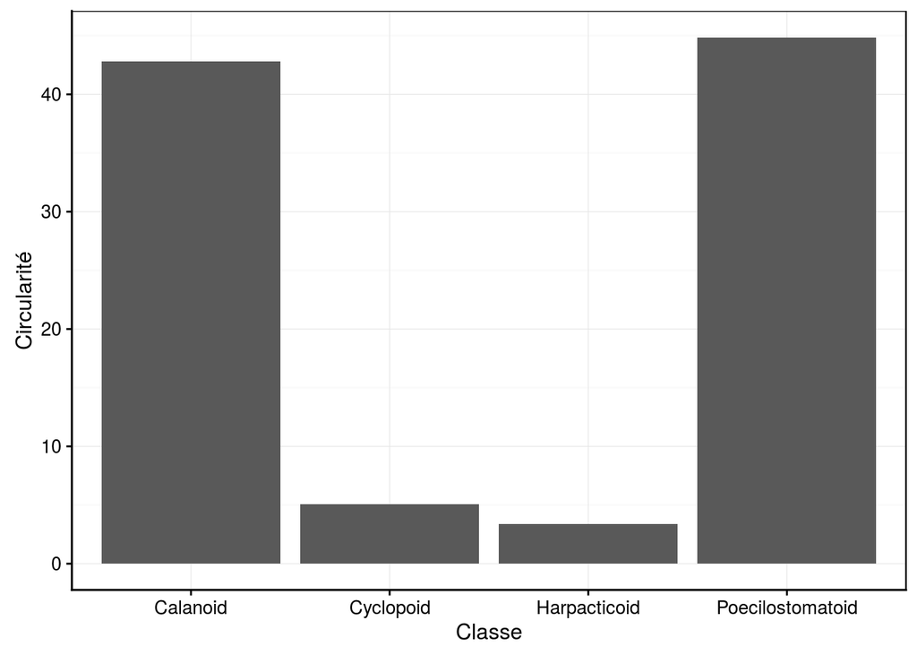

```r
chart(zooplankton_sub, formula =  circularity ~ class ) +
  geom_col()
```

On peut voir que les Calanoïdes et Poécilostomatoïdes ont presque la même circularité et que les Cyclopïdes et les Harpaticoïdes ont presque la même circularité entre eux aussi.

## 5.9 Statiistiques

### 5.9.1 ANOVA de la surface des individus en fonction de l’ordre de copépodes

```r
anova(anova. <- lm(data = zooplankton_sub, area ~ class))
```

```
## Analysis of Variance Table
##
## Response: area
##            Df Sum Sq Mean Sq F value    Pr(>F)
## class       3  6.481 2.16040  20.783 9.585e-13 ***
## Residuals 531 55.199 0.10395
## ---
## Signif. codes:  0 '***' 0.001 '**' 0.01 '*' 0.05 '.' 0.1 ' ' 1
```

H0 : tous les ordres sont significativement identiques pour la surface (homoscédasticité)

Ici, nous devons rejeter H0 car la valeur de P est grandement inférieure au seuil alpha qui est de 5% (ANOVA, F = 20, ddl = 3 & 531 valeur P << 10-3).

### 5.9.2 Test post-hoc de Tukey pour la surface des individus en fonction de l’ordre de copépodes

```r
summary(anovaComp. <- confint(multcomp::glht(anova.,
  linfct = multcomp::mcp(class = "Tukey"))))
```

```
##
##   Simultaneous Tests for General Linear Hypotheses
##
## Multiple Comparisons of Means: Tukey Contrasts
##
##
## Fit: lm(formula = area ~ class, data = zooplankton_sub)
##
## Linear Hypotheses:
##                                      Estimate Std. Error t value Pr(>|t|)
## Cyclopoid - Calanoid == 0            -0.27794    0.04940  -5.627   <0.001
## Harpacticoid - Calanoid == 0         -0.10660    0.05501  -1.938   0.2019
## Poecilostomatoid - Calanoid == 0     -0.21313    0.03192  -6.677   <0.001
## Harpacticoid - Cyclopoid == 0         0.17134    0.06888   2.488   0.0585
## Poecilostomatoid - Cyclopoid == 0     0.06481    0.05232   1.239   0.5876
## Poecilostomatoid - Harpacticoid == 0 -0.10653    0.05765  -1.848   0.2393
##
## Cyclopoid - Calanoid == 0            ***
## Harpacticoid - Calanoid == 0
## Poecilostomatoid - Calanoid == 0     ***
## Harpacticoid - Cyclopoid == 0        .
## Poecilostomatoid - Cyclopoid == 0
## Poecilostomatoid - Harpacticoid == 0
## ---
## Signif. codes:  0 '***' 0.001 '**' 0.01 '*' 0.05 '.' 0.1 ' ' 1
## (Adjusted p values reported -- single-step method)
```

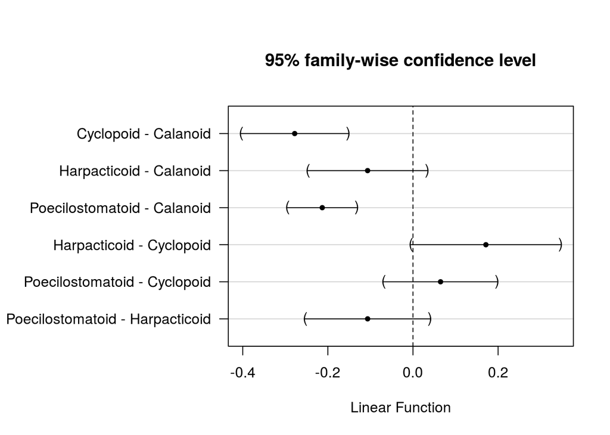

```r
.oma <- par(oma = c(0, 9, 2, 0)); plot(anovaComp.); par(.oma); rm(.oma)
```

Suite au rejet de H0 dans le test de l’ANOVA, un test poc-hoc s’annonce. En effet, si l’on sait qu’au moins deux moyennes diffèrent, nous ne savons toujours pas lesquelles.

Le test post-hoc de tukey montre ici sur le graphique que les Cyclopoïdes et Calanoïdes diffèrent significativement entre eux, ainsi que les Calanoïdes et les Poécilostomatoïdes entre eux, concernant la surface. Toutes les autres comparaisons deux à deux ne sont pas significativement différentes.

Pour résumer, les seuls ordres à différer significativement entre eux sont les Cyclopoïdes et Calanoïdes ainsi que les Calanoïdes et les Poécilostomatoïdes.

### 5.9.3 ANOVA de la densité optique des individus en fonction de l’ordre de copépodes

```r
anova(anova. <- lm(data = zooplankton_sub, density ~ class))
```

```
## Analysis of Variance Table
##
## Response: density
##            Df  Sum Sq Mean Sq F value    Pr(>F)
## class       3 0.37772 0.12591  22.482 1.023e-13 ***
## Residuals 531 2.97381 0.00560
## ---
## Signif. codes:  0 '***' 0.001 '**' 0.01 '*' 0.05 '.' 0.1 ' ' 1
```

H0 : tous les ordres sont significativement identiques pour la densité optique (homoscédasticité)

### 5.9.4 Test post-hoc de Tukey pour la densité optique des individus en fonction de l’ordre de copépodes

```r
summary(anovaComp. <- confint(multcomp::glht(anova.,
  linfct = multcomp::mcp(class = "Tukey"))))
```

```
##
##   Simultaneous Tests for General Linear Hypotheses
##
## Multiple Comparisons of Means: Tukey Contrasts
##
##
## Fit: lm(formula = density ~ class, data = zooplankton_sub)
##
## Linear Hypotheses:
##                                       Estimate Std. Error t value Pr(>|t|)
## Cyclopoid - Calanoid == 0            -0.087822   0.011465  -7.660  < 0.001
## Harpacticoid - Calanoid == 0         -0.041973   0.012769  -3.287  0.00569
## Poecilostomatoid - Calanoid == 0     -0.029312   0.007409  -3.956  < 0.001
## Harpacticoid - Cyclopoid == 0         0.045849   0.015988   2.868  0.02028
## Poecilostomatoid - Cyclopoid == 0     0.058510   0.012143   4.818  < 0.001
## Poecilostomatoid - Harpacticoid == 0  0.012661   0.013381   0.946  0.76938
##
## Cyclopoid - Calanoid == 0            ***
## Harpacticoid - Calanoid == 0         **
## Poecilostomatoid - Calanoid == 0     ***
## Harpacticoid - Cyclopoid == 0        *
## Poecilostomatoid - Cyclopoid == 0    ***
## Poecilostomatoid - Harpacticoid == 0
## ---
## Signif. codes:  0 '***' 0.001 '**' 0.01 '*' 0.05 '.' 0.1 ' ' 1
## (Adjusted p values reported -- single-step method)
```

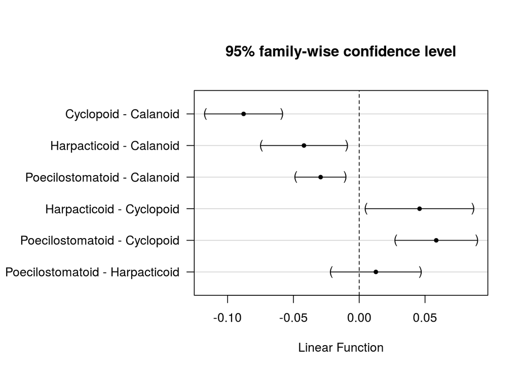

```r
.oma <- par(oma = c(0, 9, 2, 0)); plot(anovaComp.); par(.oma); rm(.oma)
```

# 6 Conclusion

Les graphiques montrent presque tous de “grosses” différences entre les Calanoïdes et les autres ordres de Copépodes. Les test d’ANOVA et de Tukey confirme ce que disent les graphiques en montrant que les Calanoïdes diffèrent significativement des Cyclopoïdes et des Poécilostomatoïdes pour l’aire et significativement différents des Harpaticoïdes, Cyclopoïdes et des Poécilostomatoïdes.

Je conclue que l’ordre de copépodes influe sur les paramètres corporels des individus.